# jost-gwps-example

## Mapping cells at the group-level

We can start by trying to map cells from the query data to GWPS at the group-level, where cells of the same condition can be assigned together. Here, we map cells according to their perturbation labels, and obtain a dataframe summarizing these assignments. This can be slow due to the size of GWPS, but faster results can be obtained using parallelization with the `mc.cores` parameter.

```r
jost <- FingerprintCells(jost,
                         condition_meta = 'gene',
                         control_class = 'neg',
                         dictionary = gwps_dictionary,
                         group_level = TRUE)
```

```
#> The following 541 features are not present in the SCT assay:LINC01128, INTS11, MRPL20-AS1, FNDC10, CENPS, SPEN-AS1, MICOS10, ELOA-AS1, ELOA, MACO1, ATP5IF1, SNHG3, YARS1, TMEM35B, ADPRS, UTP11, TUT4, CZIB, IFT25, MIGA1, SELENOF, KYAT3, LINC02609, DPH5-DT, EEIG2, SARS1, ATP5PB, LINC02802, LINC0280…
#> Processing data...
#> Preparing...
#> Classifying...
```

```r
group_level_summary <- SummarizeResults(jost, group_level = TRUE,
                                         condition_meta = 'gene',
                                         control_class = 'neg')
print(group_level_summary[1:5,])
```

```
#>                                                                                                                                                                                                                                  top_credible_set.gene
#> RPL9                                                                                                                    SPATA5L1,URB2,ABCF1,NLE1,SPATA5,RPL3,CENPP,HERC1,EIF6,SURF6,DDX51,TMA16,CINP,RSL1D1,MYBBP1A,CARF,UBE2E1,KRR1,NOC3L,FBXL14,RPL9
#> GATA1                                                                                                                                                                                                                                     HMBOX1,GATA1
#> POLR1D                                                                                                                                                                                   TAF1C,RPL3,TAF1D,GTF3C6,POLR1E,POLR1C,CD3EAP,RPL26,GNL2,RPL37
#> POLR2H                                                                                                                                                                                             UXT,NUMA1,C1QBP,PFDN2,MED26,RPAP2,POLR2B,ERCC2,GPN3
#> RPS14  KRR1,WDR3,FBXL14,AATF,RIOK1,RPS12,RIOK2,DDX52,DIMT1,DDX10,ZNF84,FCF1,RPS3,WDR36,NOP10,RPS14,RPS2,RPS19,DDX47,TSR2,RPP30,POP4,RRP9,POP1,ZNHIT6,USP36,UTP20,RPS3A,DNTTIP2,RPS20,RPS15A,ABT1,IMPA2,RPP14,ZCCHC9,ESF1,BUD23,LAMB1,RPS10-NUDT3,RRP12
#>        top_lbf.gene
#> RPL9        2882.97
#> GATA1       2762.02
#> POLR1D      2093.92
#> POLR2H      2056.41
#> RPS14       1900.83
#>                                                                                                                                                                                                                                 all_credible_sets.gene
#> RPL9                                                                                                                    SPATA5L1,URB2,ABCF1,NLE1,SPATA5,RPL3,CENPP,HERC1,EIF6,SURF6,DDX51,TMA16,CINP,RSL1D1,MYBBP1A,CARF,UBE2E1,KRR1,NOC3L,FBXL14,RPL9
#> GATA1                                                                                                                                                                                                                                     HMBOX1,GATA1
#> POLR1D                                                                                                                                                                                   TAF1C,RPL3,TAF1D,GTF3C6,POLR1E,POLR1C,CD3EAP,RPL26,GNL2,RPL37
#> POLR2H                                                                                                                                                                                             UXT,NUMA1,C1QBP,PFDN2,MED26,RPAP2,POLR2B,ERCC2,GPN3
#> RPS14  KRR1,WDR3,FBXL14,AATF,RIOK1,RPS12,RIOK2,DDX52,DIMT1,DDX10,ZNF84,FCF1,RPS3,WDR36,NOP10,RPS14,RPS2,RPS19,DDX47,TSR2,RPP30,POP4,RRP9,POP1,ZNHIT6,USP36,UTP20,RPS3A,DNTTIP2,RPS20,RPS15A,ABT1,IMPA2,RPP14,ZCCHC9,ESF1,BUD23,LAMB1,RPS10-NUDT3,RRP12
#>        all_lbfs.gene
#> RPL9         2882.97
#> GATA1        2762.02
#> POLR1D       2093.92
#> POLR2H       2056.41
#> RPS14        1900.83
#>                                                                         all_signs.gene
#> RPL9                                         +,+,+,+,+,+,+,+,+,+,+,+,+,+,+,+,+,+,+,+,+
#> GATA1                                                                              +,+
#> POLR1D                                                             +,+,+,+,+,+,+,+,+,+
#> POLR2H                                                               +,+,+,+,+,+,+,+,+
#> RPS14  +,+,+,+,+,+,+,+,+,+,+,+,+,+,+,+,+,+,+,+,+,+,+,+,+,+,+,+,+,+,+,+,+,+,+,+,+,+,+,+
```

Some of these assignments involve very long credible sets, which makes sense given that many of these perturbations are of genes belonging to large complexes. We can visualize these assignments using Long Island City plots. Below, we should an example of an assignment with a long credible set, and one with a short credible set. We could alternatively sort the fingerprints in alphabetical order by setting the `order` argument appropriately.

```r
LongIslandCityPlot(jost, query = 'RPS14', condition_meta = 'gene',
                   control_class = 'neg', dictionary = gwps_dictionary,
                   group_level = T, cs = 10)
LongIslandCityPlot(jost, query = 'BCR', condition_meta = 'gene',
                   control_class = 'neg', dictionary = gwps_dictionary,
                   group_level = T, cs = 10)
```

[output not shown]

[output not shown]

These plots show the conditional posterior mean coefficients for each fingerprint on the y-axis. However, in large-scale settings, this can be slow to compute. For a faster version, we can specify the argument `approx = TRUE` to instead show marginal correlations on the y-axis, e.g.:

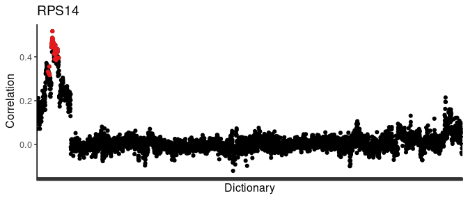

```r
LongIslandCityPlot(jost, query = 'RPS14', condition_meta = 'gene',
                   control_class = 'neg', dictionary = gwps_dictionary,
                   group_level = T, cs = 10, approx = TRUE)
```

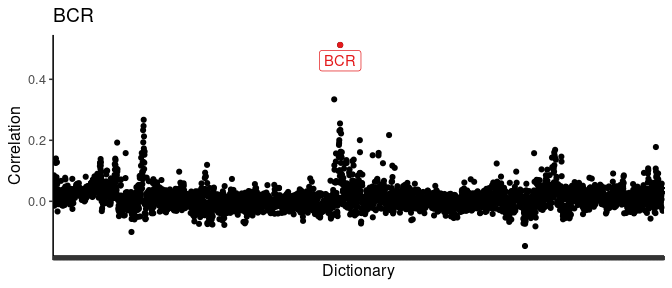

```r
LongIslandCityPlot(jost, query = 'BCR', condition_meta = 'gene',
                   control_class = 'neg', dictionary = gwps_dictionary,
                   group_level = T, cs = 10, approx = TRUE)
```

To understand what genes were most responsible for driving these matches, we can use the `ExplainMatch` function. Here, the visualizations are automatically made with the stored pseudobulk GWPS object inside the precomputed dictionary, since we don’t have the full GWPS object loaded in.

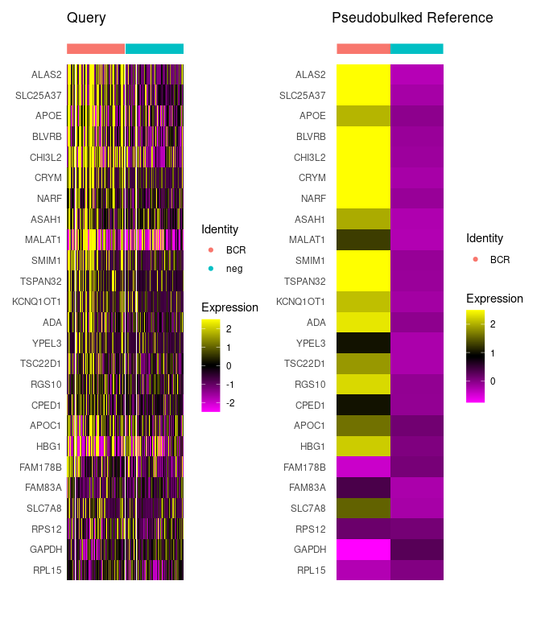

```r
ExplainMatch(jost, query = 'BCR', match = 'BCR',
             condition_meta = 'gene', control_class = 'neg',
             dictionary = gwps_dictionary, group_level = T,
             num_genes = 25)
```

## Mapping cells individually

We can also map cells on an individual basis. This will be slower than group-level classification, so here we speed it up by using parallelization with `mc.cores`.

```r
jost <- FingerprintCells(jost, condition_meta = 'gene', control_class = 'neg',
                         dictionary = gwps_dictionary,
                         group_level = FALSE, mc.cores = 10)
```

```
#> The following 541 features are not present in the SCT assay:LINC01128, INTS11, MRPL20-AS1, FNDC10, CENPS, SPEN-AS1, MICOS10, ELOA-AS1, ELOA, MACO1, ATP5IF1, SNHG3, YARS1, TMEM35B, ADPRS, UTP11, TUT4, CZIB, IFT25, MIGA1, SELENOF, KYAT3, LINC02609, DPH5-DT, EEIG2, SARS1, ATP5PB, LINC02802, LINC0280…
#> Processing data...
#> Preparing...
#> Classifying...
```

```r
cell_level_summary <- SummarizeResults(jost, group_level = FALSE,
                                       condition_meta = 'gene',
                                       control_class = 'neg')
print(head(cell_level_summary))
```

```
#>                    gene
#> GCAGTTACAAGCTGGA-2 RPL9
#> CAGTAACAGAGGGCTT-2 RPL9
#> GGGTTGCCACGTCTCT-2 RPL9
#> GACACGCTCAGCTCTC-2 RPL9
#> TGTTCCGTCGTTGCCT-2 RPL9
#> ATCACGACAGGTCGTC-2 RPL9
#>                                                                                                                                                                                                                                                                             top_credible_set
#> GCAGTTACAAGCTGGA-2                                                                                                                                             ABCF1,RPL30,RPL19,RPL10,RPL8,RPL21,RPL14,RPL24,RPL9,URB2,EIF6,DDX51,NLE1,TEX10,SPATA5L1,MYBBP1A,CINP,RPL37,PPAN,RPL10A,HEATR1
#> CAGTAACAGAGGGCTT-2     ABCF1,NLE1,DDX24,EIF6,RPL8,RPL5,RPL36,RPL24,RPL30,SPATA5L1,CINP,URB2,CENPP,NIFK,SDAD1,GNL2,FBL,RPS7,TSR2,RPS3,RPS4X,KRR1,UTP20,RPS15A,EIF3A,RPS6,RPS24,TTF1,GLIS1,PES1,MYBBP1A,SOX3,WDR12,RPL18,STK24,NOC3L,CARF,DDX51,RRS1,DDX54,NOP16,MAK16,RPL34,RPL7,FBXL14,RPL21
#> GGGTTGCCACGTCTCT-2                                                                                                        NLE1,DDX51,ABCF1,MYBBP1A,EIF6,RRS1,RPL37,RPL30,RPL10,RPL24,RPL8,GNL2,RPL17,SOX3,DDX54,CCDC86,SDAD1,NOC3L,RPL9,RPL36,RPL18,NSA2,SPATA5L1,NOP2,RPL19,RPL14,RPL7,CINP
#> GACACGCTCAGCTCTC-2                                                                                    URB2,SPATA5L1,ABCF1,DDX55,LTV1,HERC1,SDAD1,RPS19,RPS10-NUDT3,NOC3L,TEX10,TMA16,NOLC1,HDAC6,RPL3,SURF6,RSL1D1,EIF6,CINP,DDX52,TSR2,KRR1,RCL1,HIGD2A,FCF1,TPP2,EIF3C,DNTTIP2,RPS12,MAK16
#> TGTTCCGTCGTTGCCT-2 URB2,NLE1,GNL2,ABCF1,RPL24,NOL9,SPATA5L1,KIF18B,CINP,ZSCAN2,RPL18,NR2F2,DDX56,RPS20,EIF5B,GLIS1,RPL21,SOX3,CEBPZ,DDX24,NOL8,RBM28,NIFK,RRS1,MDN1,UBE2E1,GTPBP4,RPL27,NOC3L,LAS1L,WDR55,TEX10,RPL18A,LTV1,PES1,RSL24D1,RPL11,RPL13,SURF6,RPL23A,TPP2,SPATA5,DDX54,NVL,NMD3
#> ATCACGACAGGTCGTC-2                                                                                              SDAD1,NLE1,RPL37,EIF6,GNL2,RRS1,RPL24,URB2,RPL30,RPL5,RPL10,RPL17,RPL13,RPL38,RPL31,RPLP0,GLIS1,DDX56,RPL11,DDX24,ABCF1,NOP16,MAK16,SPATA5L1,DDX51,CINP,EBNA1BP2,RPL18,WDR12
#>                    top_lbf
#> GCAGTTACAAGCTGGA-2 1077.60
#> CAGTAACAGAGGGCTT-2  594.60
#> GGGTTGCCACGTCTCT-2  491.14
#> GACACGCTCAGCTCTC-2  491.08
#> TGTTCCGTCGTTGCCT-2  475.88
#> ATCACGACAGGTCGTC-2  474.95
#>                                                                                                                                                                                                                                                                            all_credible_sets
#> GCAGTTACAAGCTGGA-2                                                                                                                                             ABCF1,RPL30,RPL19,RPL10,RPL8,RPL21,RPL14,RPL24,RPL9,URB2,EIF6,DDX51,NLE1,TEX10,SPATA5L1,MYBBP1A,CINP,RPL37,PPAN,RPL10A,HEATR1
#> CAGTAACAGAGGGCTT-2     ABCF1,NLE1,DDX24,EIF6,RPL8,RPL5,RPL36,RPL24,RPL30,SPATA5L1,CINP,URB2,CENPP,NIFK,SDAD1,GNL2,FBL,RPS7,TSR2,RPS3,RPS4X,KRR1,UTP20,RPS15A,EIF3A,RPS6,RPS24,TTF1,GLIS1,PES1,MYBBP1A,SOX3,WDR12,RPL18,STK24,NOC3L,CARF,DDX51,RRS1,DDX54,NOP16,MAK16,RPL34,RPL7,FBXL14,RPL21
#> GGGTTGCCACGTCTCT-2                                                                                                        NLE1,DDX51,ABCF1,MYBBP1A,EIF6,RRS1,RPL37,RPL30,RPL10,RPL24,RPL8,GNL2,RPL17,SOX3,DDX54,CCDC86,SDAD1,NOC3L,RPL9,RPL36,RPL18,NSA2,SPATA5L1,NOP2,RPL19,RPL14,RPL7,CINP
#> GACACGCTCAGCTCTC-2                                                                                    URB2,SPATA5L1,ABCF1,DDX55,LTV1,HERC1,SDAD1,RPS19,RPS10-NUDT3,NOC3L,TEX10,TMA16,NOLC1,HDAC6,RPL3,SURF6,RSL1D1,EIF6,CINP,DDX52,TSR2,KRR1,RCL1,HIGD2A,FCF1,TPP2,EIF3C,DNTTIP2,RPS12,MAK16
#> TGTTCCGTCGTTGCCT-2 URB2,NLE1,GNL2,ABCF1,RPL24,NOL9,SPATA5L1,KIF18B,CINP,ZSCAN2,RPL18,NR2F2,DDX56,RPS20,EIF5B,GLIS1,RPL21,SOX3,CEBPZ,DDX24,NOL8,RBM28,NIFK,RRS1,MDN1,UBE2E1,GTPBP4,RPL27,NOC3L,LAS1L,WDR55,TEX10,RPL18A,LTV1,PES1,RSL24D1,RPL11,RPL13,SURF6,RPL23A,TPP2,SPATA5,DDX54,NVL,NMD3
#> ATCACGACAGGTCGTC-2                                                                                              SDAD1,NLE1,RPL37,EIF6,GNL2,RRS1,RPL24,URB2,RPL30,RPL5,RPL10,RPL17,RPL13,RPL38,RPL31,RPLP0,GLIS1,DDX56,RPL11,DDX24,ABCF1,NOP16,MAK16,SPATA5L1,DDX51,CINP,EBNA1BP2,RPL18,WDR12
#>                    all_lbfs
#> GCAGTTACAAGCTGGA-2   1077.6
#> CAGTAACAGAGGGCTT-2    594.6
#> GGGTTGCCACGTCTCT-2   491.14
#> GACACGCTCAGCTCTC-2   491.08
#> TGTTCCGTCGTTGCCT-2   475.88
#> ATCACGACAGGTCGTC-2   474.95
#>                                                                                                      all_signs
#> GCAGTTACAAGCTGGA-2                                                   +,+,+,+,+,+,+,+,+,+,+,+,+,+,+,+,+,+,+,+,+
#> CAGTAACAGAGGGCTT-2 +,+,+,+,+,+,+,+,+,+,+,+,+,+,+,+,+,+,+,+,+,+,+,+,+,+,+,+,+,+,+,+,+,+,+,+,+,+,+,+,+,+,+,+,+,+
#> GGGTTGCCACGTCTCT-2                                     +,+,+,+,+,+,+,+,+,+,+,+,+,+,+,+,+,+,+,+,+,+,+,+,+,+,+,+
#> GACACGCTCAGCTCTC-2                                 +,+,+,+,+,+,+,+,+,+,+,+,+,+,+,+,+,+,+,+,+,+,+,+,+,+,+,+,+,+
#> TGTTCCGTCGTTGCCT-2   +,+,+,+,+,+,+,+,+,+,+,+,+,+,+,+,+,+,+,+,+,+,+,+,+,+,+,+,+,+,+,+,+,+,+,+,+,+,+,+,+,+,+,+,+
#> ATCACGACAGGTCGTC-2                                   +,+,+,+,+,+,+,+,+,+,+,+,+,+,+,+,+,+,+,+,+,+,+,+,+,+,+,+,+
```

We can visualize these assignments by using the `ProjectFingerprints` function to create a UMAP of the projections of each assigned cell onto the fingerprints. Below, we overlay the plot with each cell’s true perturbation label:

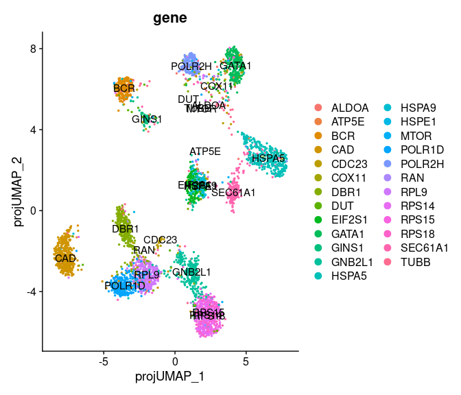

```r
jost <- ProjectFingerprints(jost, 'gene',
                            'neg', gwps_dictionary)
DimPlot(jost, group.by = 'gene',
        reduction = 'projUMAP', label = T)
```